# Recreational physical activity in US adults

Dataset 10: NHANES adults (2009-10 and 2011-12 extract)

RSR feasibility analysis

2026-08-03

# Introduction

The National Health and Nutrition Examination Survey (NHANES) is a continuous cross-sectional survey of the civilian non-institutionalised US population, pairing a household interview with a standardised examination. This teaching extract holds 488 adults aged 21 to 80 from the 2009-10 and 2011-12 cycles, of whom 241 (49.4%) report doing moderate or vigorous recreational physical activity. Physical inactivity is a leading modifiable risk factor for cardiovascular disease and diabetes, and describing *who* is inactive is the standard first step in targeting activity promotion programmes.

**Aim.** Among these US adults, we examined which of age, sex, race/ethnicity, education, income-to-poverty ratio, BMI, self-rated general health and smoking history are independently associated with reporting recreational physical activity, mutually adjusting for the others.

This is a *Purpose 3* analysis: several predictors are of interest and the question is which remain associated with the outcome after mutual adjustment. Note that this is a **behavioural surveillance question, not a clinical one**: the outcome is a self-reported behaviour, and the sensible reading of the results is descriptive (which groups report low activity) rather than causal.

# Methods

**Data source.** NHANES 2009-10 and 2011-12, a complex multistage probability sample of the US civilian non-institutionalised population. This extract contains 488 adults with 31 variables. The activity question was asked in the household interview.

**Variables.** The outcome is `phys_active`, a binary indicator where the **event is reporting moderate or vigorous recreational physical activity** (241 events in the full file). Predictors are age (years), sex (reference female), race/ethnicity (reference White, the largest group), education (reference College Grad, the largest group), income-to-poverty ratio, BMI (kg/m2), self-rated general health collapsed to three levels (reference Excellent/Very good) and ever having smoked 100 cigarettes (reference no).

**`phys_active` is the outcome here and is therefore not a predictor.** It is listed as a suggested predictor elsewhere in this catalogue; in this file it has been removed from the predictor set entirely.

`weight_kg` and `height_cm` are excluded because `bmi` is exactly `weight_kg / (height_cm/100)^2` in this file; `obese` is excluded because it is exactly `bmi >= 30`.

**Statistical analysis.** `glm(family = binomial)`, justified because the outcome is binary. We fitted a univariable model for each predictor first, then a single multivariable model containing all of them. Predictors were chosen in advance on subject-matter grounds, not by significance. Coefficients are exponentiated and reported as odds ratios with 95% confidence intervals; significance threshold 0.05. Model adequacy was assessed with `performance::check_model()`, focusing on binned residuals, collinearity, influential observations and events per parameter. Models are **unweighted**: the NHANES survey weights, strata and primary sampling units are not carried in this extract, so no result here is a nationally representative estimate. Analysis used R version 4.6.0 (2026-04-24) with tidyverse, gtsummary and performance.

**Missing data.** Complete-case analysis: 411 of 488 rows were analysed (77 dropped), leaving 203 events. The loss comes from `general_health` (48 missing) and `poverty_ratio` (38 missing). Only 172 of 488 rows are complete on *every* variable in the file, so listwise deletion is a live threat and the complete-case N is reported for every model.

# Results

## Sample characteristics

**Table 1. Sample characteristics by physical activity.**

| **Characteristic** | **N** | **Not active** N = 208<sup>1</sup> | **Active** N = 203<sup>1</sup> |
| --- | --- | --- | --- |
| Age (years) | 411 | 53 (39, 69) | 48 (34, 59) |
| Sex | 411 |  |  |
| Female |  | 119 (57%) | 98 (48%) |
| Male |  | 89 (43%) | 105 (52%) |
| Race/ethnicity | 411 |  |  |
| White |  | 146 (70%) | 155 (76%) |
| Black |  | 25 (12%) | 21 (10%) |
| Hispanic |  | 6 (2.9%) | 11 (5.4%) |
| Mexican |  | 22 (11%) | 8 (3.9%) |
| Other |  | 9 (4.3%) | 8 (3.9%) |
| Education | 411 |  |  |
| College Grad |  | 42 (20%) | 89 (44%) |
| Some College |  | 64 (31%) | 58 (29%) |
| High School |  | 48 (23%) | 35 (17%) |
| 9 - 11th Grade |  | 36 (17%) | 15 (7.4%) |
| 8th Grade |  | 18 (8.7%) | 6 (3.0%) |
| Income-to-poverty ratio | 411 | 2.64 (1.39, 4.23) | 3.77 (1.98, 5.00) |
| BMI (kg/m2) | 411 | 29 (26, 35) | 28 (24, 32) |
| Self-rated general health | 411 |  |  |
| Excellent/Very good |  | 79 (38%) | 113 (56%) |
| Good |  | 91 (44%) | 71 (35%) |
| Fair/Poor |  | 38 (18%) | 19 (9.4%) |
| Ever smoked 100+ cigarettes | 411 | 95 (46%) | 90 (44%) |

<sup>1</sup> Median (Q1, Q3); n (%)

The clearest difference is educational: college graduates make up a much larger share of the active group than of the inactive group. Active participants are also younger, leaner, better off on the income-to-poverty ratio and more likely to rate their health as Excellent or Very good. Smoking history is similar in the two groups.

## Exploratory figure

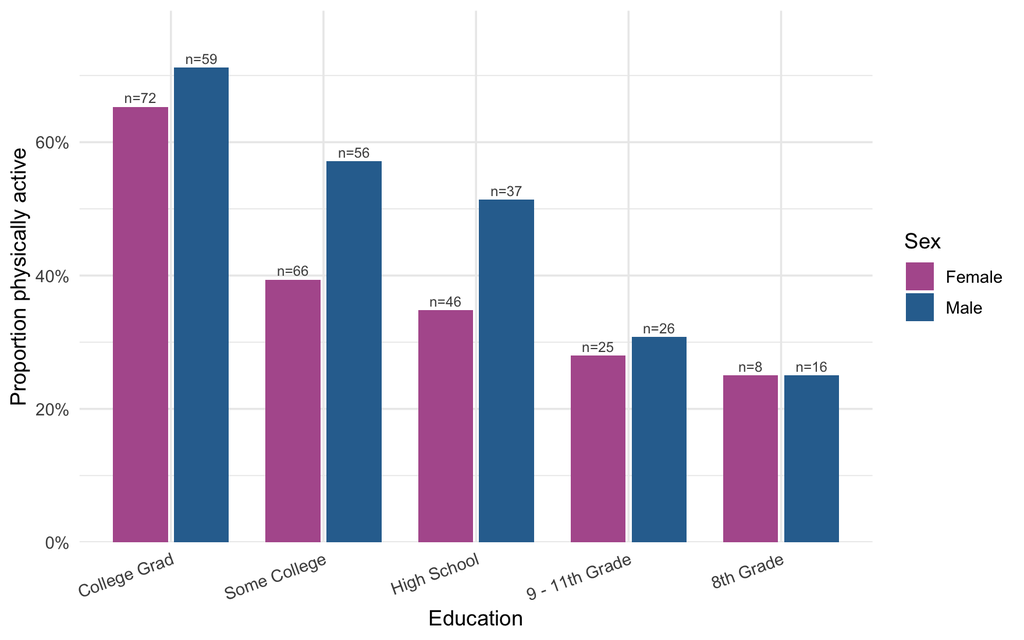

Figure 1. Proportion reporting recreational physical activity by education and sex.

There is a steep educational gradient: roughly two thirds of college graduates report recreational activity against about a quarter of those with 8th-grade education, in both sexes, and the lowest education cells are small (n as low as 8).

## Univariable models

| **Characteristic** | **N** | **OR** | **95% CI** | **p-value** |
| --- | --- | --- | --- | --- |
| Age (years) | 411 | 0.98 | 0.97, 0.99 | 0.002 |
| Sex | 411 |  |  |  |
| Female |  | — | — |  |
| Male |  | 1.43 | 0.97, 2.12 | 0.070 |
| Race/ethnicity | 411 |  |  |  |
| White |  | — | — |  |
| Black |  | 0.79 | 0.42, 1.47 | 0.5 |
| Hispanic |  | 1.73 | 0.64, 5.12 | 0.3 |
| Mexican |  | 0.34 | 0.14, 0.76 | 0.012 |
| Other |  | 0.84 | 0.31, 2.25 | 0.7 |
| Education | 411 |  |  |  |
| College Grad |  | — | — |  |
| Some College |  | 0.43 | 0.26, 0.71 | 0.001 |
| High School |  | 0.34 | 0.19, 0.61 | <0.001 |
| 9 - 11th Grade |  | 0.20 | 0.09, 0.39 | <0.001 |
| 8th Grade |  | 0.16 | 0.05, 0.40 | <0.001 |
| Income-to-poverty ratio | 411 | 1.29 | 1.14, 1.47 | <0.001 |
| BMI (kg/m2) | 411 | 0.95 | 0.93, 0.98 | 0.002 |
| Self-rated general health | 411 |  |  |  |
| Excellent/Very good |  | — | — |  |
| Good |  | 0.55 | 0.36, 0.83 | 0.005 |
| Fair/Poor |  | 0.35 | 0.18, 0.64 | <0.001 |
| Ever smoked 100+ cigarettes | 411 |  |  |  |
| No |  | — | — |  |
| Yes |  | 0.95 | 0.64, 1.40 | 0.8 |

Abbreviations: CI = Confidence Interval, OR = Odds Ratio

Education dominates the crude picture. Relative to college graduates, the odds of reporting activity are OR 0.43 (95% CI 0.26 to 0.71) for some college (p = 0.001), OR 0.34 (95% CI 0.19 to 0.61) for high school (p <0.001), OR 0.20 (95% CI 0.09 to 0.39) for 9th-11th grade (p <0.001) and OR 0.16 (95% CI 0.05 to 0.40) for 8th grade (p <0.001) - a monotone gradient spanning more than a fivefold difference in odds. Each unit of income-to-poverty ratio is associated with OR 1.29 (95% CI 1.14 to 1.47) (p <0.001), each year of age with OR 0.98 (95% CI 0.97 to 0.99) (p = 0.002) and each kg/m2 of BMI with OR 0.95 (95% CI 0.93 to 0.98) (p = 0.002). Worse self-rated health is associated with lower odds (Good OR 0.55 (95% CI 0.36 to 0.83), p = 0.005; Fair/Poor OR 0.35 (95% CI 0.18 to 0.64), p <0.001). Sex and smoking show no crude association.

## Why adjustment is needed

**Education** is the confounder that matters most here, because it is associated with almost every other predictor. Better-educated participants have higher income-to-poverty ratios by construction of the labour market, lower BMI, better self-rated health and a different age and ethnic distribution; since education is also strongly associated with the outcome, the crude income, BMI and general-health coefficients are all partly educational gradients in disguise. **Income-to-poverty ratio** confounds the race/ethnicity contrasts for the same reason: minority groups in this sample have lower income-to-poverty ratios, and low income is associated with low reported activity, so a crude Mexican-versus-White comparison partly measures income. Mutual adjustment lets each odds ratio be read as a comparison between participants alike on the other measured characteristics.

A caveat that adjustment cannot fix: **BMI and self-rated general health are plausibly consequences of physical activity rather than causes of it.** In a cross-sectional file we cannot tell which came first, and conditioning on a downstream variable biases the remaining coefficients unpredictably. They are retained here because the question is descriptive - who reports low activity? - rather than causal, but no coefficient in this model should be read as an effect.

## Multivariable model

| **Characteristic** | **OR** | **95% CI** | **p-value** |
| --- | --- | --- | --- |
| Age (years) | 0.98 | 0.97, 0.99 | 0.002 |
| Sex |  |  |  |
| Female | — | — |  |
| Male | 1.50 | 0.97, 2.32 | 0.071 |
| Race/ethnicity |  |  |  |
| White | — | — |  |
| Black | 0.94 | 0.47, 1.87 | 0.8 |
| Hispanic | 2.29 | 0.76, 7.61 | 0.2 |
| Mexican | 0.50 | 0.17, 1.40 | 0.2 |
| Other | 0.54 | 0.17, 1.62 | 0.3 |
| Education |  |  |  |
| College Grad | — | — |  |
| Some College | 0.45 | 0.26, 0.78 | 0.005 |
| High School | 0.40 | 0.21, 0.76 | 0.005 |
| 9 - 11th Grade | 0.25 | 0.11, 0.55 | <0.001 |
| 8th Grade | 0.30 | 0.08, 0.98 | 0.052 |
| Income-to-poverty ratio | 1.13 | 0.97, 1.31 | 0.13 |
| BMI (kg/m2) | 0.96 | 0.93, 0.99 | 0.019 |
| Self-rated general health |  |  |  |
| Excellent/Very good | — | — |  |
| Good | 0.78 | 0.48, 1.26 | 0.3 |
| Fair/Poor | 0.78 | 0.38, 1.61 | 0.5 |
| Ever smoked 100+ cigarettes |  |  |  |
| No | — | — |  |
| Yes | 1.25 | 0.80, 1.97 | 0.3 |

Abbreviations: CI = Confidence Interval, OR = Odds Ratio

**Model fit: multivariable logistic model for physical activity**

| Statistic | Value |
| --- | --- |
| Complete-case N | 411 |
| Events (active = 1) | 203 |
| Non-events | 208 |
| Parameters (excl. intercept) | 15 |
| Events per parameter (smaller class) | 13.5 |
| AIC (null model) | 571.7 |
| AIC (full model) | 535.2 |
| Tjur's R-squared | 0.152 |

The outcome is close to balanced (203 active, 208 not), so the binding count for the events-per-parameter rule is the smaller class: 203 for 15 parameters, i.e. **13.5 per parameter**, above the conventional minimum of ten. AIC falls from 571.7 for the intercept-only model to 535.2, a drop of 36.5; Tjur’s R-squared is 0.152.

Among participants of the same age, sex, race, income, BMI, health rating and smoking history, the educational gradient persists almost undiminished: relative to college graduates, the odds of reporting activity are OR 0.45 (95% CI 0.26 to 0.78) for some college (p = 0.005), OR 0.40 (95% CI 0.21 to 0.76) for high school (p = 0.005) and OR 0.25 (95% CI 0.11 to 0.55) for 9th-11th grade (p <0.001). Each year of age is associated with OR 0.98 (95% CI 0.97 to 0.99) (p = 0.002) and each kg/m2 of BMI with OR 0.96 (95% CI 0.93 to 0.99) (p = 0.019). Income-to-poverty ratio (OR 1.13 (95% CI 0.97 to 1.31)), self-rated health (Good OR 0.78 (95% CI 0.48 to 1.26); Fair/Poor OR 0.78 (95% CI 0.38 to 1.61)), sex (OR 1.50 (95% CI 0.97 to 2.32)), smoking (OR 1.25 (95% CI 0.80 to 1.97)) and all race/ethnicity contrasts are no longer independently associated. These are associations among the participants observed, not effects of intervening.

## Unadjusted versus adjusted

**Table 2. Unadjusted and adjusted odds ratios.**

| **Characteristic** | **Unadjusted** **N** | **Unadjusted** **OR** | **Unadjusted** **95% CI** | **Unadjusted** **p-value** | **Adjusted** **OR** | **Adjusted** **95% CI** | **Adjusted** **p-value** |
| --- | --- | --- | --- | --- | --- | --- | --- |
| Age (years) | 411 | 0.98 | 0.97, 0.99 | 0.002 | 0.98 | 0.97, 0.99 | 0.002 |
| Sex | 411 |  |  |  |  |  |  |
| Female |  | — | — |  | — | — |  |
| Male |  | 1.43 | 0.97, 2.12 | 0.070 | 1.50 | 0.97, 2.32 | 0.071 |
| Race/ethnicity | 411 |  |  |  |  |  |  |
| White |  | — | — |  | — | — |  |
| Black |  | 0.79 | 0.42, 1.47 | 0.5 | 0.94 | 0.47, 1.87 | 0.8 |
| Hispanic |  | 1.73 | 0.64, 5.12 | 0.3 | 2.29 | 0.76, 7.61 | 0.2 |
| Mexican |  | 0.34 | 0.14, 0.76 | 0.012 | 0.50 | 0.17, 1.40 | 0.2 |
| Other |  | 0.84 | 0.31, 2.25 | 0.7 | 0.54 | 0.17, 1.62 | 0.3 |
| Education | 411 |  |  |  |  |  |  |
| College Grad |  | — | — |  | — | — |  |
| Some College |  | 0.43 | 0.26, 0.71 | 0.001 | 0.45 | 0.26, 0.78 | 0.005 |
| High School |  | 0.34 | 0.19, 0.61 | <0.001 | 0.40 | 0.21, 0.76 | 0.005 |
| 9 - 11th Grade |  | 0.20 | 0.09, 0.39 | <0.001 | 0.25 | 0.11, 0.55 | <0.001 |
| 8th Grade |  | 0.16 | 0.05, 0.40 | <0.001 | 0.30 | 0.08, 0.98 | 0.052 |
| Income-to-poverty ratio | 411 | 1.29 | 1.14, 1.47 | <0.001 | 1.13 | 0.97, 1.31 | 0.13 |
| BMI (kg/m2) | 411 | 0.95 | 0.93, 0.98 | 0.002 | 0.96 | 0.93, 0.99 | 0.019 |
| Self-rated general health | 411 |  |  |  |  |  |  |
| Excellent/Very good |  | — | — |  | — | — |  |
| Good |  | 0.55 | 0.36, 0.83 | 0.005 | 0.78 | 0.48, 1.26 | 0.3 |
| Fair/Poor |  | 0.35 | 0.18, 0.64 | <0.001 | 0.78 | 0.38, 1.61 | 0.5 |
| Ever smoked 100+ cigarettes | 411 |  |  |  |  |  |  |
| No |  | — | — |  | — | — |  |
| Yes |  | 0.95 | 0.64, 1.40 | 0.8 | 1.25 | 0.80, 1.97 | 0.3 |

Abbreviations: CI = Confidence Interval, OR = Odds Ratio

Two predictors are wiped out by adjustment. Self-rated health Fair/Poor moves from OR 0.35 (95% CI 0.18 to 0.64) (p <0.001) to OR 0.78 (95% CI 0.38 to 1.61) (p = 0.503) - more than three quarters of the way to the null - and income-to-poverty ratio moves from OR 1.29 (95% CI 1.14 to 1.47) (p <0.001) to OR 1.13 (95% CI 0.97 to 1.31) (p = 0.127). Both are explained by education: the crude health and income associations were mostly the education gradient showing through. The Mexican-versus-White contrast tells the same story, moving from OR 0.34 (95% CI 0.14 to 0.76) (p = 0.012) to OR 0.50 (95% CI 0.17 to 1.40) (p = 0.194) and losing significance, which is confounding by education and income. By contrast the education contrasts themselves barely move (some college OR 0.43 (95% CI 0.26 to 0.71) to OR 0.45 (95% CI 0.26 to 0.78); 9th-11th grade OR 0.20 (95% CI 0.09 to 0.39) to OR 0.25 (95% CI 0.11 to 0.55)), and age is almost unchanged (OR 0.98 (95% CI 0.97 to 0.99) to OR 0.98 (95% CI 0.97 to 0.99)). BMI attenuates only slightly, from OR 0.95 (95% CI 0.93 to 0.98) to OR 0.96 (95% CI 0.93 to 0.99), and stays significant. Nothing crosses into significance on adjustment.

## Diagnostics

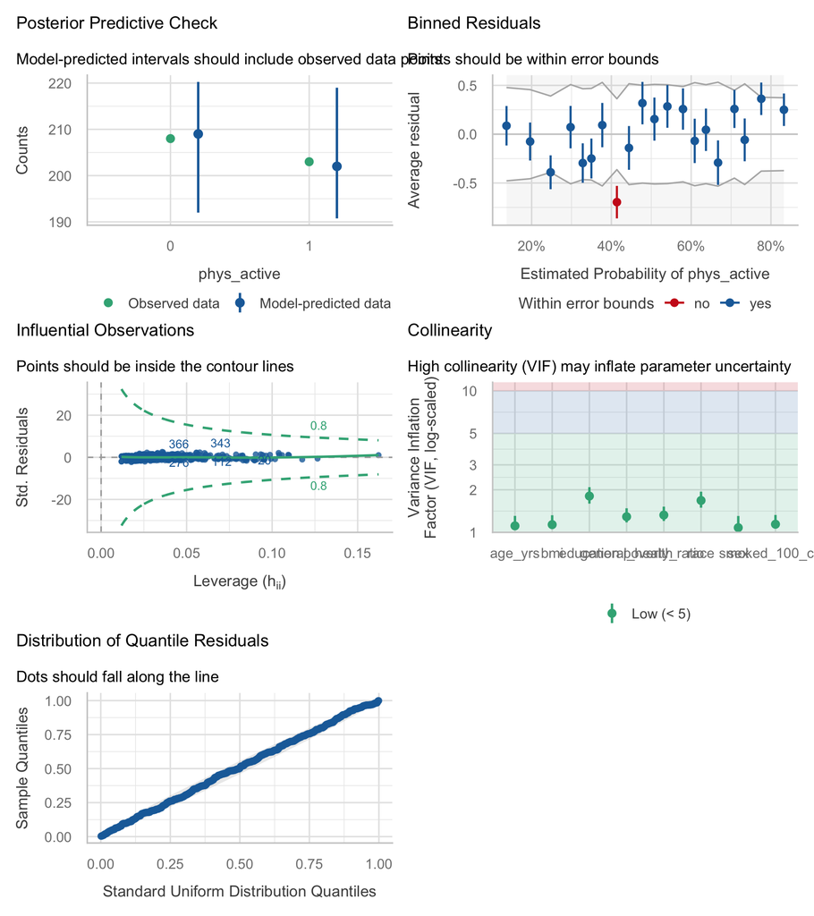

```
## Ok: About 95% of the residuals are inside the error bounds.
```

| Term | VIF | VIF_CI_low | VIF_CI_high | SE_factor | Tolerance | Tolerance_CI_low | Tolerance_CI_high |
| --- | --- | --- | --- | --- | --- | --- | --- |
| age_yrs | 1.112119 | 1.040905 | 1.307311 | 1.054570 | 0.8991847 | 0.7649288 | 0.9607025 |
| sex | 1.079848 | 1.020883 | 1.305300 | 1.039157 | 0.9260561 | 0.7661075 | 0.9795437 |
| race | 1.680845 | 1.494239 | 1.937906 | 1.067065 | 0.5949389 | 0.5160208 | 0.6692371 |
| education | 1.805377 | 1.597029 | 2.086432 | 1.076641 | 0.5539010 | 0.4792872 | 0.6261626 |
| poverty_ratio | 1.325497 | 1.203765 | 1.519952 | 1.151302 | 0.7544342 | 0.6579155 | 0.8307269 |
| bmi | 1.134742 | 1.056449 | 1.321622 | 1.065243 | 0.8812579 | 0.7566458 | 0.9465671 |
| general_health | 1.290822 | 1.176003 | 1.480546 | 1.065900 | 0.7746999 | 0.6754267 | 0.8503376 |
| smoked_100_cigs | 1.141744 | 1.061427 | 1.327073 | 1.068524 | 0.8758533 | 0.7535379 | 0.9421275 |

The binned-residual check passes: about 95% of binned residuals fall inside the error bounds, so predicted probabilities are reasonably well calibrated across the range - helped by the near-50/50 outcome split, which spreads predictions across the middle of the probability scale where the model is best behaved. Collinearity is acceptable but not negligible: the highest VIF is about 1.8, for `education`, followed by 1.7 for race and 1.3 for income-to-poverty ratio. Those first two are four-degree-of-freedom terms, and their *adjusted* VIFs (which rescale for the number of parameters) are both about 1.1, so the inflation is mild. Still, education and income are correlated enough that the income standard error is inflated, which contributes to that coefficient losing significance: the null income result should be read as “not separable from education” rather than “no association”. No observation crosses the influence contours (maximum Cook’s distance 0.031, maximum leverage 0.162). There is no separation: all coefficients are finite with standard errors below 0.63, and every category contains both active and inactive participants - although the 8th-grade stratum has only 6 active participants out of 24, which is why its confidence interval is by far the widest in the table. Homogeneity of variance and normality of residuals do not apply to a logistic model and are not interpreted.

# Discussion

**Limitations.** The models are unweighted, and the NHANES sampling weights, strata and PSUs are not in this extract, so the sample **must not be described as nationally representative**. The outcome is a bare self-reported yes/no with no frequency, duration or intensity, so it cannot distinguish a weekly walk from daily training, and it excludes occupational and transport activity entirely - which biases the comparison against manual workers, who are concentrated in the low-education groups, and therefore probably exaggerates the education gradient. Social-desirability bias in self-reported exercise is well documented and may differ by education. The design is cross-sectional and two of the predictors (BMI, self-rated health) are as plausibly *consequences* of activity as causes of it, so the model conditions on downstream variables and no coefficient can be read causally. Complete-case analysis dropped 77 of 488 rows (16%). The 8th-grade and Other/Hispanic strata are small, so those contrasts are imprecise. Income-to-poverty ratio and education are collinear enough (VIF ~1.8) that their separate contributions cannot really be distinguished. All estimates are associations, not causal effects.

**Future work.** Refit with the NHANES survey design and with the accelerometer or activity-minutes variables from the full public files, which would replace the yes/no outcome with a graded measure.

# Feasibility notes

*NOT part of a student report.*